# EPH

Licenciatura en Ciencias de Datos - UNSAM

Visualización de datos en R

Septiembre 2025

Marcelo Gabriel Ulrich

2025-09-14

# Clase 6: Encuesta Permanente de Hogares

### Paquetes

```r
library(eph)
library(ggplot2)
library(dplyr)
library(forcats)
library(tidyr)
library(ggridges)
library(treemapify)


knitr::opts_chunk$set(message = FALSE, warning = FALSE, comment = "")
options(scipen = 999)
```

### Datos

```r
data_1t <- get_microdata(year = 2024, trimester = 1, type = 'individual')
data_2t <- get_microdata(year = 2024, trimester = 2, type = 'individual')
data_3t <- get_microdata(year = 2024, trimester = 3, type = 'individual')

data <- rbind(data_1t, data_2t, data_3t)

data <- organize_labels(data, type = "individual")

data
```

```
# A tibble: 140,765 × 177
   CODUSU   ANO4  TRIMESTRE NRO_HOGAR COMPONENTE H15   REGION MAS_500 AGLOMERADO
   <labell> <lab> <labelle> <labelle> <labelled> <lab> <labe> <label> <labelled>
 1 TQRMNOP… 2024  1         1         3          1     42     S       10
 2 TQRMNOP… 2024  1         1         4          1     42     S       10
 3 TQRMNOP… 2024  1         1         5          0     42     S       10
 4 TQRMNOP… 2024  1         1         1          1     42     S       10
 5 TQRMNOP… 2024  1         1         2          1     42     S       10
 6 TQRMNOP… 2024  1         1         3          1     42     S       10
 7 TQRMNOP… 2024  1         1         4          1     42     S       10
 8 TQRMNOR… 2024  1         1         1          1     41     N        7
 9 TQRMNOR… 2024  1         1         2          1     41     N        7
10 TQRMNOR… 2024  1         1         3          1     41     N        7
# ℹ 140,755 more rows
# ℹ 168 more variables: PONDERA <labelled>, CH03 <labelled>, CH04 <labelled>,
#   CH05 <labelled>, CH06 <labelled>, CH07 <labelled>, CH08 <labelled>,
#   CH09 <labelled>, CH10 <labelled>, CH11 <labelled>, CH12 <labelled>,
#   CH13 <labelled>, CH14 <labelled>, CH15 <labelled>, CH15_COD <labelled>,
#   CH16 <labelled>, CH16_COD <labelled>, NIVEL_ED <labelled>,
#   ESTADO <labelled>, CAT_OCUP <labelled>, CAT_INAC <labelled>, …
```

### Ejercicio 1

¿Cómo se distribuyen los estados ocupacionales por género?

Realizá un gráfico de barras, utilizá colores y funciones necesarias para formatear los datos logrando su correcta visualización.

Tené en cuenta que hay que filtrar aquellos casos que no corresponden (los menores de 10 años).

Entiendiendo los estados ocupacionales como Ocupado, Desocupado e Inactivo, necesito usar la variable ESTADO y CH04. Entiendo, segun la documentación de la clase, ESTADO solo se aplica para mayores de 10 años, por lo que no debería haber problemas, pero por las dudas chequeo.

Pruebo de usar la función de la libería EPH, genera las tabulaciones en base a los datos.

```r
calculate_tabulates(data, x = "ESTADO", y = "CH04", add.totals = "none", add.percentage = "col")
```

```
# A tibble: 5 × 3
  `ESTADO/CH04`                                                      Varon Mujer
  <fct>                                                              <dbl> <dbl>
1 Entrevista individual no realizada (no respuesta al cuestionario …   0.2   0.1
2 Ocupado                                                             50.5  38.2
3 Desocupado                                                           3.3   2.7
4 Inactivo                                                            33.2  47.8
5 Menor de 10 anios.                                                  12.8  11.2
```

Entiendo que como importe los datos a nivel individuo, debería usar el PONDIIO como parametro weights

```r
calculate_tabulates(data, x = "ESTADO", y = "CH04", weights = "PONDIIO", add.totals = "none", add.percentage = "col")
```

```
# A tibble: 5 × 3
  `ESTADO/CH04`                                                      Varon Mujer
  <fct>                                                              <dbl> <dbl>
1 Entrevista individual no realizada (no respuesta al cuestionario …   0.3   0.2
2 Ocupado                                                             51.1  38.7
3 Desocupado                                                           3.7   3.5
4 Inactivo                                                            30.3  44.8
5 Menor de 10 anios.                                                  14.6  12.9
```

No hay mucha diferencia, pero aun así es clave hacerlo.

Ahora sí, figuran los menores de 10 años y los que no se les realizo el cuestionario individual. Los filtro y vuelvo a correr

```r
data_ej1 <- calculate_tabulates(filter(data, ! ESTADO %in% c("4", "0")), x = "ESTADO", y = "CH04", weights = "PONDIIO", add.totals = "none", add.percentage = "col")
data_ej1
```

```
# A tibble: 3 × 3
  `ESTADO/CH04` Varon Mujer
  <fct>         <dbl> <dbl>
1 Ocupado        60.1  44.5
2 Desocupado      4.3   4
3 Inactivo       35.6  51.5
```

Me fijo a cuantos dejé afuera (para tenerlo en cuenta)

```r
nrow(filter(data, ESTADO %in% c("4", "0")))
```

```
[1] 17022
```

Modifico para graficar

```r
data_ej1 <- data_ej1 %>%
  pivot_longer(
    cols = c("Varon", "Mujer"),
    names_to= "Sexo",
    values_to = "Porcentaje"
  ) %>%
  rename(Estado = "ESTADO/CH04")
```

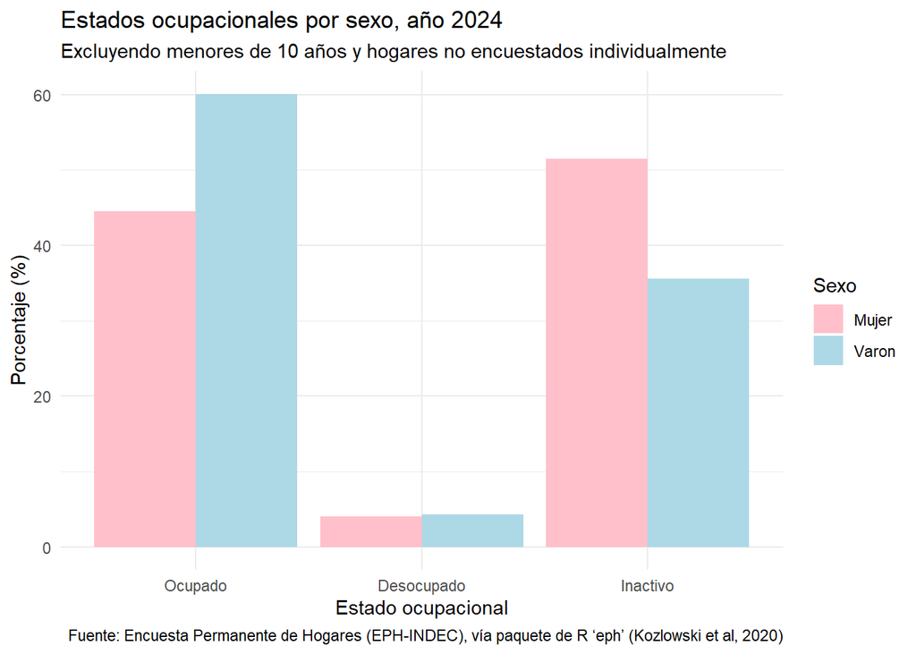

```r
# Crear el gráfico de barras agrupadas
ggplot(data_ej1, aes(x = Estado, y = Porcentaje, fill = Sexo)) +
  geom_bar(stat = "identity", position = "dodge") +
  labs(
    title = "Estados ocupacionales por sexo, año 2024",
    subtitle = "Excluyendo menores de 10 años y hogares no encuestados individualmente",
    x = "Estado ocupacional",
    y = "Porcentaje (%)",
    fill = "Sexo",
    caption = "Fuente: Encuesta Permanente de Hogares (EPH-INDEC), vía paquete de R ‘eph’ (Kozlowski et al, 2020)"
  ) +
  scale_fill_manual(values = c("Varon" = "lightblue", "Mujer" = "pink"))+
  theme_minimal()
```

Listo, no?

### Ejercicio 2

Mostrá en un gráfico la distribución de probabilidad de la variable ingresos de asalariados según región. De nuevo, tené en cuenta con filtrar aquellos casos que no corresponden (los no-asalariados).

Los datos necesarios son: - P21 → Ingreso individual de la ocupación principal. - ESTADO == “1” para ocupados - CAT_OCUP == “3” para asalariados - REGION

```r
data_ej2 <- data[,c("P21", "ESTADO", "CAT_OCUP", "REGION")]
data_ej2 <- filter(data_ej2, ESTADO == "1" & CAT_OCUP == "3")
data_ej2
```

```
# A tibble: 45,752 × 4
   P21        ESTADO     CAT_OCUP   REGION
   <labelled> <labelled> <labelled> <labelled>
 1     -9     1          3          42
 2 250000     1          3          42
 3 200000     1          3          42
 4 200000     1          3          42
 5 200000     1          3          42
 6     -9     1          3          41
 7     -9     1          3          41
 8 200000     1          3          41
 9     -9     1          3          41
10 500000     1          3          41
# ℹ 45,742 more rows
```

Oh no! Hay salarios -9… Qué significa?

```r
filter(data, P21 == "-9")
```

```
# A tibble: 11,059 × 177
   CODUSU   ANO4  TRIMESTRE NRO_HOGAR COMPONENTE H15   REGION MAS_500 AGLOMERADO
   <labell> <lab> <labelle> <labelle> <labelled> <lab> <labe> <label> <labelled>
 1 TQRMNOP… 2024  1         1         3          1     42     S       10
 2 TQRMNOR… 2024  1         1         2          1     41     N        7
 3 TQRMNOR… 2024  1         1         3          1     41     N        7
 4 TQRMNOS… 2024  1         1         1          1     41     N        7
 5 TQRMNOS… 2024  1         1         3          1     41     N        7
 6 TQRMNOR… 2024  1         1         1          1     43     S        5
 7 TQRMNOR… 2024  1         1         2          1     43     S        5
 8 TQRMNOS… 2024  1         1         2          1     41     N        7
 9 TQRMNOS… 2024  1         2         2          1     41     N        7
10 TQRMNOS… 2024  1         2         3          1     41     N        7
# ℹ 11,049 more rows
# ℹ 168 more variables: PONDERA <labelled>, CH03 <labelled>, CH04 <labelled>,
#   CH05 <labelled>, CH06 <labelled>, CH07 <labelled>, CH08 <labelled>,
#   CH09 <labelled>, CH10 <labelled>, CH11 <labelled>, CH12 <labelled>,
#   CH13 <labelled>, CH14 <labelled>, CH15 <labelled>, CH15_COD <labelled>,
#   CH16 <labelled>, CH16_COD <labelled>, NIVEL_ED <labelled>,
#   ESTADO <labelled>, CAT_OCUP <labelled>, CAT_INAC <labelled>, …
```

No tengo idea, fuí a revisar si había algo sobre eso y no encontré nada… Decido filtrarlo y listo.

```r
data_ej2 <- data[,c("P21", "ESTADO", "CAT_OCUP", "REGION")]
data_ej2 <- filter(data_ej2, ESTADO == "1" & CAT_OCUP == "3" & P21 != "-9")
data_ej2
```

```
# A tibble: 38,448 × 4
   P21        ESTADO     CAT_OCUP   REGION
   <labelled> <labelled> <labelled> <labelled>
 1 250000     1          3          42
 2 200000     1          3          42
 3 200000     1          3          42
 4 200000     1          3          42
 5 200000     1          3          41
 6 500000     1          3          41
 7 350000     1          3          40
 8 100000     1          3          40
 9 180000     1          3          40
10 140000     1          3          40
# ℹ 38,438 more rows
```

Ahora grafico la distribución

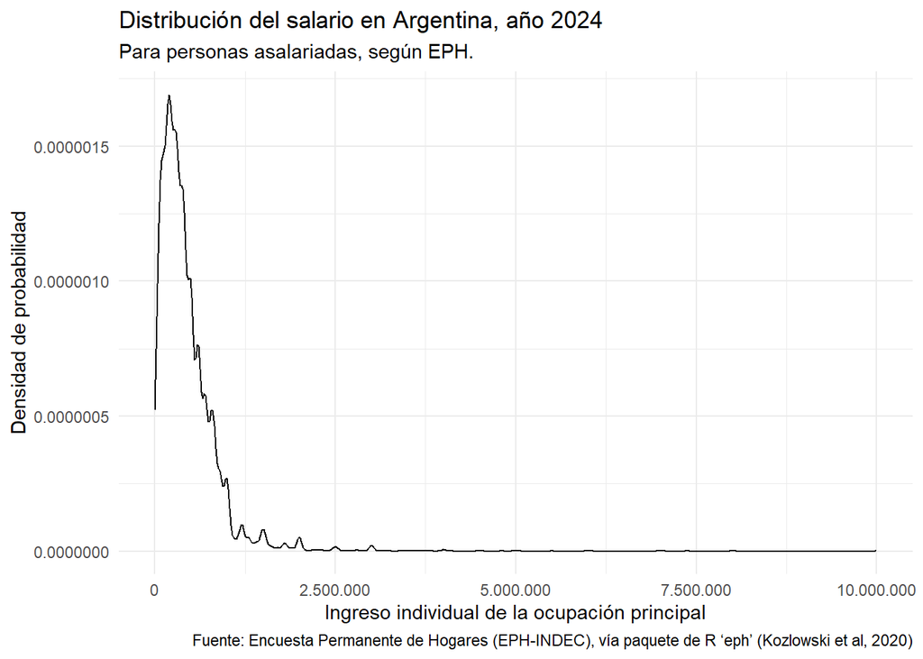

```r
ggplot(data_ej2, aes(
  x = P21))+
  geom_density()+
  scale_x_continuous(labels = scales::label_number(big.mark = ".", decimal.mark = ","))+
  theme_minimal()+
  labs(title = "Distribución del salario en Argentina, año 2024",
       subtitle = "Para personas asalariadas, según EPH.",
       x = "Ingreso individual de la ocupación principal",
       y = "Densidad de probabilidad",
       caption = "Fuente: Encuesta Permanente de Hogares (EPH-INDEC), vía paquete de R ‘eph’ (Kozlowski et al, 2020)")
```

Un parorama totalmente desalentador…

Ahora, hago un facetado por región.

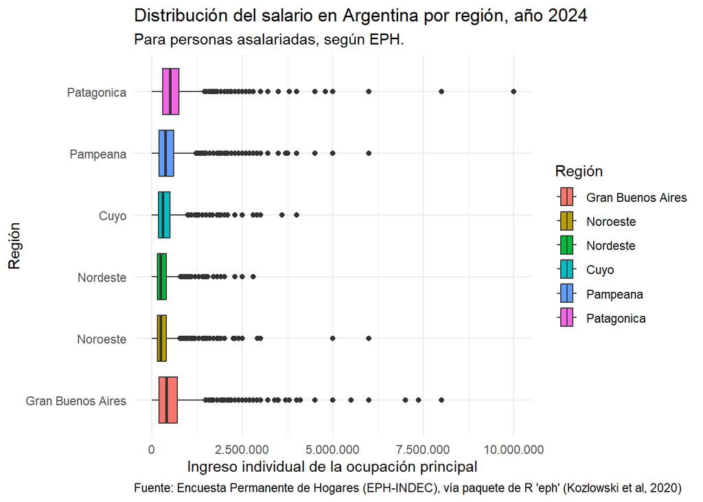

```r
ggplot(data_ej2, aes(x = P21, y = as.factor(REGION), fill = as.factor(REGION))) +
  geom_boxplot() +
  scale_x_continuous(labels = scales::label_number(big.mark = ".", decimal.mark = ",")) +
  theme_minimal() +
  labs(
    title = "Distribución del salario en Argentina por región, año 2024",
    subtitle = "Para personas asalariadas, según EPH.",
    x = "Ingreso individual de la ocupación principal",
    y = "Región",
    fill = "Región",
    caption = "Fuente: Encuesta Permanente de Hogares (EPH-INDEC), vía paquete de R 'eph' (Kozlowski et al, 2020)"
  ) +
  theme(
    plot.caption = element_text(hjust = 0)  # Align caption to the right
  )
```

Con esta manera de graficar es dificil comparar las medianas, pero las diferencias entre los outliers nos da una pauta: GBA y la Patagonia son las regiones más ricas del pais, seguidas de cerca por la llanura Pampeana.

Ahora si grafico la distribución de probabilidades, usandeo ridge

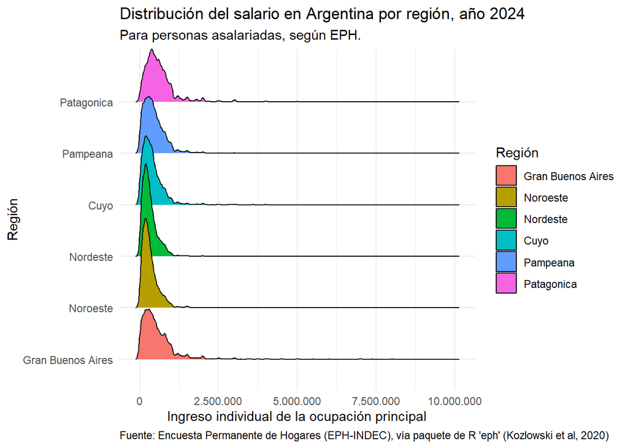

```r
ggplot(data_ej2, aes(x = P21, y = as.factor(REGION), fill = as.factor(REGION))) +
  geom_density_ridges() +
  scale_x_continuous(labels = scales::label_number(big.mark = ".", decimal.mark = ",")) +
  theme_minimal() +
  labs(
    title = "Distribución del salario en Argentina por región, año 2024",
    subtitle = "Para personas asalariadas, según EPH.",
    x = "Ingreso individual de la ocupación principal",
    y = "Región",
    fill = "Región",
    caption = "Fuente: Encuesta Permanente de Hogares (EPH-INDEC), vía paquete de R 'eph' (Kozlowski et al, 2020)"
  ) +
  theme(
    plot.caption = element_text(hjust = 0)  # Align caption to the right
  )
```

Hago zoom para los <$3M para ver mejor las diferencias

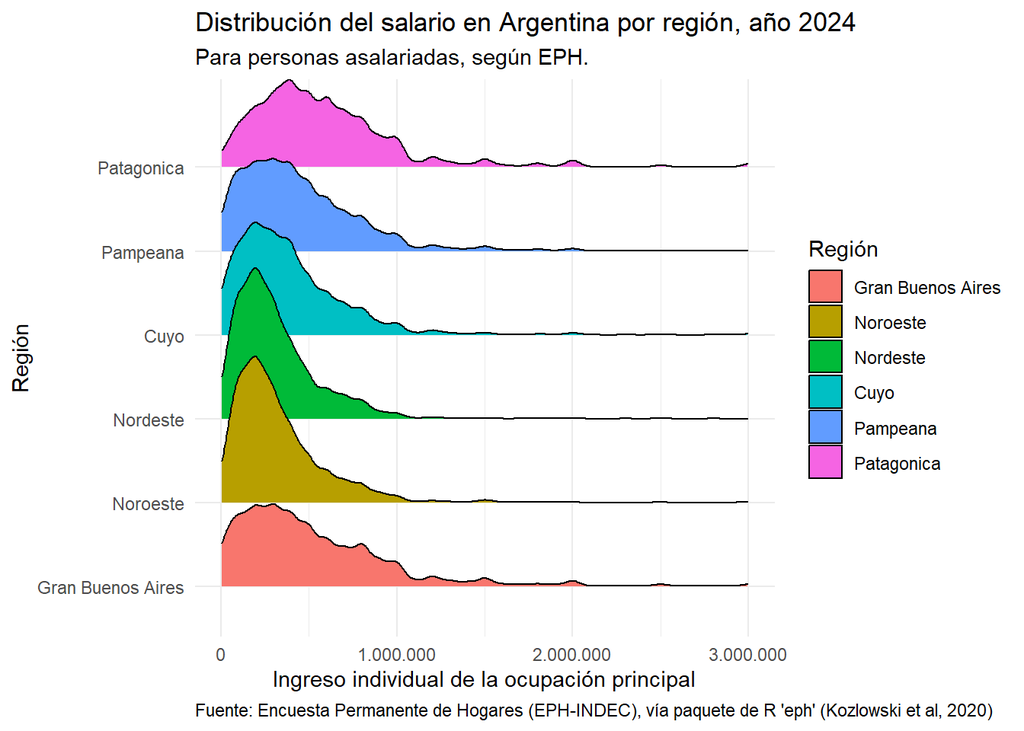

```r
ggplot(data_ej2, aes(x = P21, y = as.factor(REGION), fill = as.factor(REGION))) +
  geom_density_ridges() +
  scale_x_continuous(labels = scales::label_number(big.mark = ".", decimal.mark = ","),
                     limits = c(0, 3000000)) +
  theme_minimal() +
  labs(
    title = "Distribución del salario en Argentina por región, año 2024",
    subtitle = "Para personas asalariadas, según EPH.",
    x = "Ingreso individual de la ocupación principal",
    y = "Región",
    fill = "Región",
    caption = "Fuente: Encuesta Permanente de Hogares (EPH-INDEC), vía paquete de R 'eph' (Kozlowski et al, 2020)"
  ) +
  theme(
    plot.caption = element_text(hjust = 0)  # Align caption to the right
  )
```

Acá podemos ver más en detalle que los picos de Nordeste y Noroeste son más pronunciados y sus colas más cortas que las del resto, reforzando la noción de ser las regiones con menores ingresos para los asalariados.

### Ejercicio 3

Escapando a las barras: utilizá un boxplot para describir la relación entre el nivel de ingresos de los asalariados por región y sexo. Describí estas relaciones.

```r
data_ej3 <- data[,c("P21", "ESTADO", "CAT_OCUP", "REGION", "CH04")]
data_ej3 <- filter(data_ej3, ESTADO == "1" & CAT_OCUP == "3" & P21 != "-9")
data_ej3
```

```
# A tibble: 38,448 × 5
   P21        ESTADO     CAT_OCUP   REGION     CH04
   <labelled> <labelled> <labelled> <labelled> <labelled>
 1 250000     1          3          42         1
 2 200000     1          3          42         2
 3 200000     1          3          42         2
 4 200000     1          3          42         1
 5 200000     1          3          41         1
 6 500000     1          3          41         2
 7 350000     1          3          40         1
 8 100000     1          3          40         1
 9 180000     1          3          40         2
10 140000     1          3          40         1
# ℹ 38,438 more rows
```

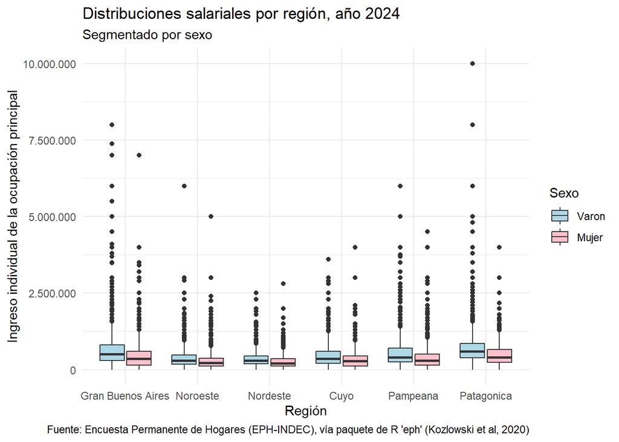

```r
ggplot(data_ej3, aes(x = as.factor(REGION), y = P21, fill = as.factor(CH04))) +
  geom_boxplot() +
  scale_fill_manual(values = c("Varon"="lightblue", "Mujer"="pink"),
                    name = "Sexo")+
  scale_y_continuous(labels = scales::label_number(big.mark = ".", decimal.mark = ","))+
  theme_minimal()+
  labs(title = "Distribuciones salariales por región, año 2024",
       subtitle = "Segmentado por sexo",
       x = "Región",
       y = "Ingreso individual de la ocupación principal",
       fill = "Género",
       caption = "Fuente: Encuesta Permanente de Hogares (EPH-INDEC), vía paquete de R 'eph' (Kozlowski et al, 2020)")
```

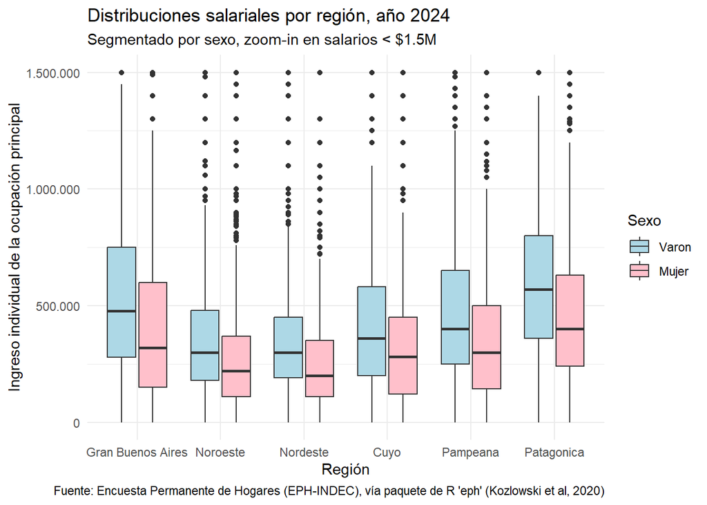

```r
ggplot(data_ej3, aes(x = as.factor(REGION), y = P21, fill = as.factor(CH04))) +
  geom_boxplot() +
  scale_y_continuous(limits = c(0, 1500000),
                     labels = scales::label_number(big.mark = ".", decimal.mark = ","))+
  scale_fill_manual(values = c("Varon"="lightblue", "Mujer"="pink"),
                    name = "Sexo")+
  theme_minimal()+
  labs(title = "Distribuciones salariales por región, año 2024",
       subtitle = "Segmentado por sexo, zoom-in en salarios < $1.5M",
       x = "Región",
       y = "Ingreso individual de la ocupación principal",
       fill = "Género",
       caption = "Fuente: Encuesta Permanente de Hogares (EPH-INDEC), vía paquete de R 'eph' (Kozlowski et al, 2020)")
```

### Ejercicio 4

Experimentá con tres recursos (“treemaps”, “enjambres de abejas”, gráficos de waffle, gráficos de violín, “ridgeline plots” o mapas de calor) aporta insights de interés sobre nuestro conjunto de datos.

Primero armo un violinplot para el ejercicio anterior

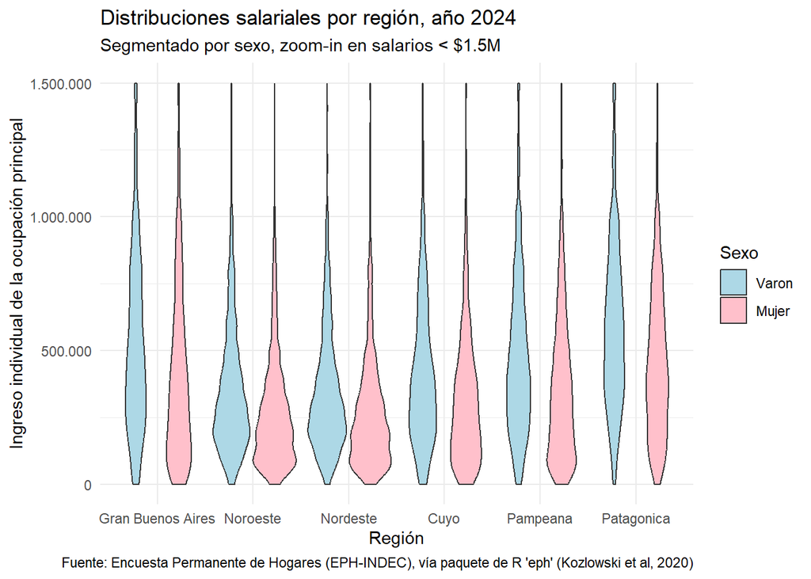

```r
ggplot(data_ej3, aes(x = as.factor(REGION), y = P21, fill = as.factor(CH04))) +
  geom_violin() +
  scale_y_continuous(limits = c(0, 1500000),
                     labels = scales::label_number(big.mark = ".", decimal.mark = ","))+
  scale_fill_manual(values = c("Varon"="lightblue", "Mujer"="pink"),
                    name = "Sexo")+
  theme_minimal()+
  labs(title = "Distribuciones salariales por región, año 2024",
       subtitle = "Segmentado por sexo, zoom-in en salarios < $1.5M",
       x = "Región",
       y = "Ingreso individual de la ocupación principal",
       fill = "Género",
       caption = "Fuente: Encuesta Permanente de Hogares (EPH-INDEC), vía paquete de R 'eph' (Kozlowski et al, 2020)")
```

Acá vemos mucho mejor cada distribución salarial. En particular me llama la atención las “pendientes” más pronunciadas de las distribuciones de varones para los deciles más bajos. Es como si no hubiese casi varones ahí.

Se me ocurre que puede ser que no sean asalariados, que figuren como cuenta propista. O quizás son esos que filtramos por no tener la variable P21 en condiciones (salario menor a cero)…

Todo esto era para los asalariados, pero ahora quiero explorar el resto de la sociedad, en particular, a los inactivos. En particular: quienes son?

```r
data_inactivos <- calculate_tabulates(filter(data, ESTADO == "3"), x = "CAT_INAC",add.percentage = "col")
data_inactivos
```

```
# A tibble: 6 × 2
  CAT_INAC               Freq
  <fct>                 <dbl>
1 Jubilado / pensionado  24.7
2 Rentista                0.6
3 Estudiante             42.9
4 Ama de casa            23.8
5 Discapacitado           2.5
6 Otros.                  5.6
```

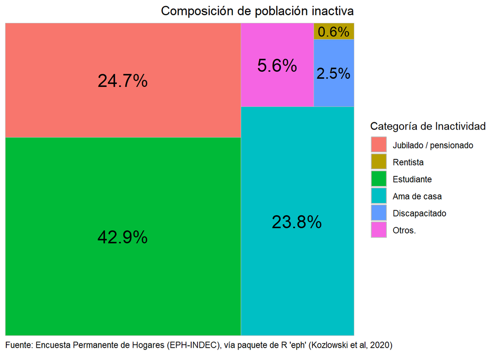

```r
library(treemapify)


ggplot(data_inactivos, aes(fill=CAT_INAC, area=Freq, label = scales::percent(Freq/100)))+
  geom_treemap()+
  geom_treemap_text(place = "center",)+
  theme_minimal()+
  labs(title="Composición de población inactiva",
       fill = "Categoría de Inactividad",
       caption = "Fuente: Encuesta Permanente de Hogares (EPH-INDEC), vía paquete de R 'eph' (Kozlowski et al, 2020)") +
  theme(
    plot.caption = element_text(hjust = 0),
    plot.title = element_text(hjust = 1)
  )
```

Estos estudiantes inactivos, son todos alumnos menores o son adultos?

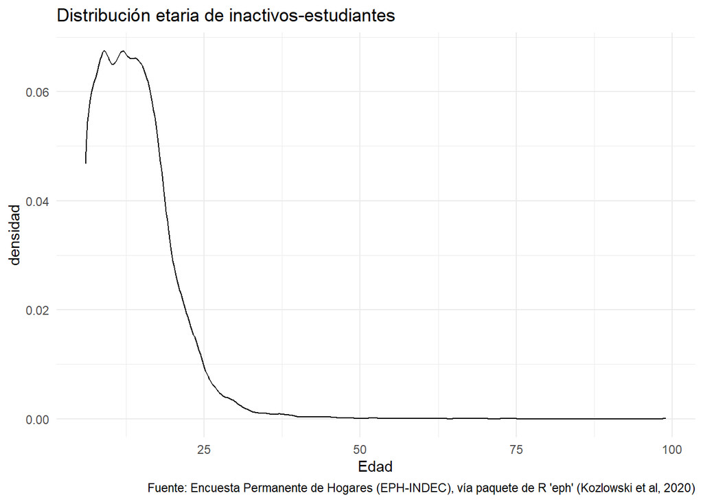

```r
ggplot(filter(data, CAT_INAC == "3"), aes(x=CH06))+
  geom_density()+
  theme_minimal()+
  labs(title = "Distribución etaria de inactivos-estudiantes",
       x = "Edad",
       y = "densidad",
       caption = "Fuente: Encuesta Permanente de Hogares (EPH-INDEC), vía paquete de R 'eph' (Kozlowski et al, 2020)"
       )
```

Era medio obvio, no?

Y la distribución etarea de estudiantes mayores de edad?

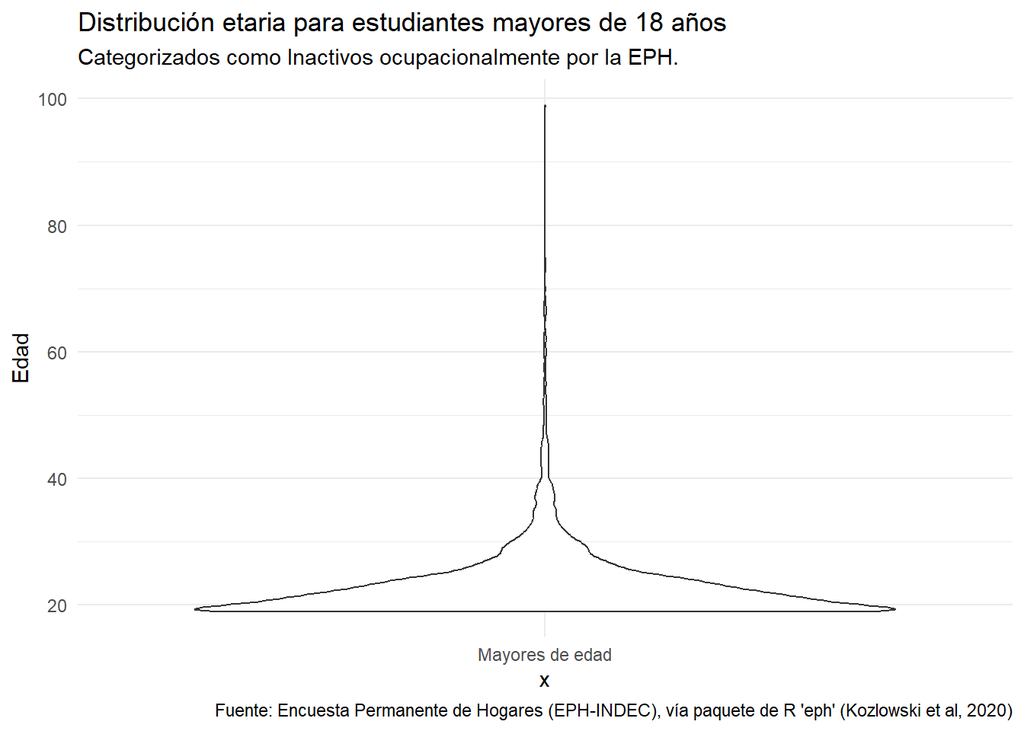

```r
ggplot(filter(data, CAT_INAC == "3" & as.numeric(CH06) > 18), aes(y=as.numeric(CH06), x="Mayores de edad"))+
  geom_violin()+
  theme_minimal()+
  labs(title="Distribución etaria para estudiantes mayores de 18 años",
       subtitle = "Categorizados como Inactivos ocupacionalmente por la EPH.",
       y = "Edad",
       caption = "Fuente: Encuesta Permanente de Hogares (EPH-INDEC), vía paquete de R 'eph' (Kozlowski et al, 2020)")
```

Efectivamente, lo esperable: los estudiantes mayores de 18 que no tienen una ocupación laboral suelen estar alrededor de los 20 años.

Muy poco analisis, lo sé. No estoy contento con esta entrega la verdad. Se me pasó y a esto es lo que llegué… Perdón profe </3